# OSM Resource

Dr. Emily Burchfield

2020-07-16

```r
library(tidyverse)
library(sf)
```

I just discovered [Geofabrik’s](https://www.geofabrik.de/) clean daily shapefiles of [OpenStreetMap data](https://www.openstreetmap.org/#map=7/23.544/90.344) for basically every country on EARTH. In this post, I’ll work with data from Bangladesh which you can download by clicking the `[.shp.zip]` file next to Bangladesh [here](http://download.geofabrik.de/asia.html). As you start playing with this data, you’ll probably also want to review the metadata for the shapefiles, which you can find here. I dropped the downloaded shapefiles in a `data` folder on my machine. Note that all files for Bangladesh are around 2.7 GB, so if you’re following along on a storage-challenged machine, you might want to go with a smaller country.

Let’s start by inspecting what’s in this folder. We can print out all of the files with extension `.shp` by running the following code (remember, this assumes you’ve moved all of your data to a `/data` sub-folder in your working directory):

```r
shp_list <- Sys.glob("./data/*.shp")
```

```r
shp_list
```

```
##  [1] "C:/Users/eburchf/OneDrive - Emory University/WF/Bangladesh/data/gis_osm_buildings_a_free_1.shp"
##  [2] "C:/Users/eburchf/OneDrive - Emory University/WF/Bangladesh/data/gis_osm_landuse_a_free_1.shp"
##  [3] "C:/Users/eburchf/OneDrive - Emory University/WF/Bangladesh/data/gis_osm_natural_a_free_1.shp"
##  [4] "C:/Users/eburchf/OneDrive - Emory University/WF/Bangladesh/data/gis_osm_natural_free_1.shp"
##  [5] "C:/Users/eburchf/OneDrive - Emory University/WF/Bangladesh/data/gis_osm_places_a_free_1.shp"
##  [6] "C:/Users/eburchf/OneDrive - Emory University/WF/Bangladesh/data/gis_osm_places_free_1.shp"
##  [7] "C:/Users/eburchf/OneDrive - Emory University/WF/Bangladesh/data/gis_osm_pofw_a_free_1.shp"
##  [8] "C:/Users/eburchf/OneDrive - Emory University/WF/Bangladesh/data/gis_osm_pofw_free_1.shp"
##  [9] "C:/Users/eburchf/OneDrive - Emory University/WF/Bangladesh/data/gis_osm_pois_a_free_1.shp"
## [10] "C:/Users/eburchf/OneDrive - Emory University/WF/Bangladesh/data/gis_osm_pois_free_1.shp"
## [11] "C:/Users/eburchf/OneDrive - Emory University/WF/Bangladesh/data/gis_osm_railways_free_1.shp"
## [12] "C:/Users/eburchf/OneDrive - Emory University/WF/Bangladesh/data/gis_osm_roads_free_1.shp"
## [13] "C:/Users/eburchf/OneDrive - Emory University/WF/Bangladesh/data/gis_osm_traffic_a_free_1.shp"
## [14] "C:/Users/eburchf/OneDrive - Emory University/WF/Bangladesh/data/gis_osm_traffic_free_1.shp"
## [15] "C:/Users/eburchf/OneDrive - Emory University/WF/Bangladesh/data/gis_osm_transport_a_free_1.shp"
## [16] "C:/Users/eburchf/OneDrive - Emory University/WF/Bangladesh/data/gis_osm_transport_free_1.shp"
## [17] "C:/Users/eburchf/OneDrive - Emory University/WF/Bangladesh/data/gis_osm_water_a_free_1.shp"
## [18] "C:/Users/eburchf/OneDrive - Emory University/WF/Bangladesh/data/gis_osm_waterways_free_1.shp"
## [19] "C:/Users/eburchf/OneDrive - Emory University/WF/Bangladesh/data/roi.shp"
```

```r
# Note that some of the shapefiles might take awhile to load
inspect_shp <- function(dir) {

  shp <- st_read(dir, quiet = T)
  print(paste0(dir, " is a ", st_geometry_type(shp)[1], " with ", nrow(shp), " observations."))

  fclass_list <- unique(shp$fclass)

  shp_plt <- ggplot(shp) +
    geom_sf() +
    theme_minimal() +
    labs(title = dir,
         subtitle = "From Geofabrik.de")

  # dump anything you want to return from the function in this list
  out_list <- list(shp, fclass_list, shp_plt)

  return(out_list)
}
```

Let’s try out our `inspect_shp()` function:

```r
out <- inspect_shp(shp_list[2])
```

```
## [1] "C:/Users/eburchf/OneDrive - Emory University/WF/Bangladesh/data/gis_osm_landuse_a_free_1.shp is a MULTIPOLYGON with 72833 observations."
```

```r
out[[2]]
```

```
##  [1] park              forest            commercial        recreation_ground
##  [5] military          retail            cemetery          industrial
##  [9] residential       nature_reserve    farm              grass
## [13] meadow            orchard           quarry            scrub
## [17] allotments        heath             vineyard
## 19 Levels: allotments cemetery commercial farm forest grass ... vineyard
```

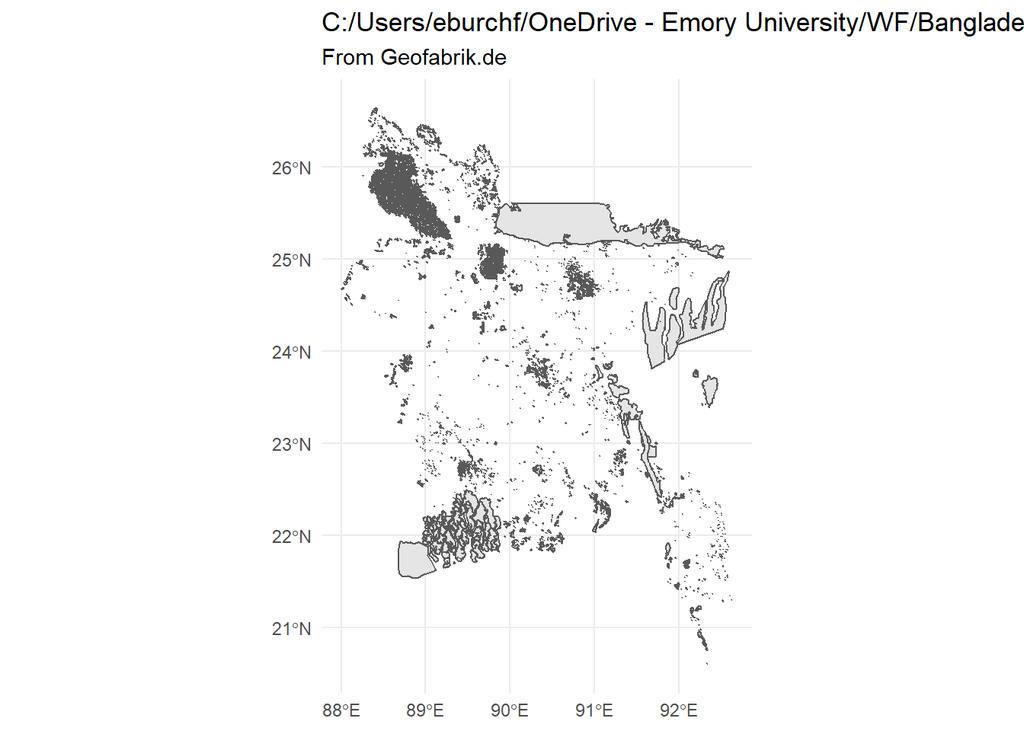

```r
out[[3]]
```

Let’s inspect some of the other datasets:

```r
places <- inspect_shp(shp_list[5])
```

```
## [1] "C:/Users/eburchf/OneDrive - Emory University/WF/Bangladesh/data/gis_osm_places_a_free_1.shp is a MULTIPOLYGON with 225 observations."
```

```r
places[[2]]
```

```
## [1] island   town     village  hamlet   locality city     suburb   farm
## Levels: city farm hamlet island locality suburb town village
```

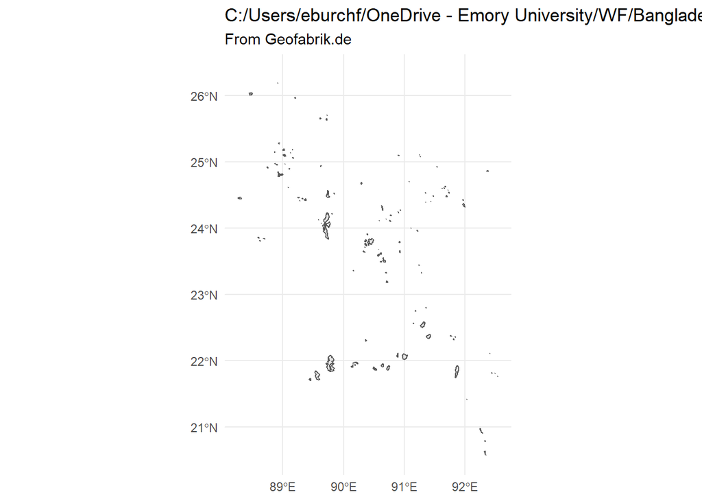

```r
places[[3]]
```

```r
water <- inspect_shp(shp_list[17])
```

```
## [1] "C:/Users/eburchf/OneDrive - Emory University/WF/Bangladesh/data/gis_osm_water_a_free_1.shp is a MULTIPOLYGON with 325559 observations."
```

```r
water[[2]]
```

```
## [1] water     river     wetland   reservoir dock
## Levels: dock reservoir river water wetland
```

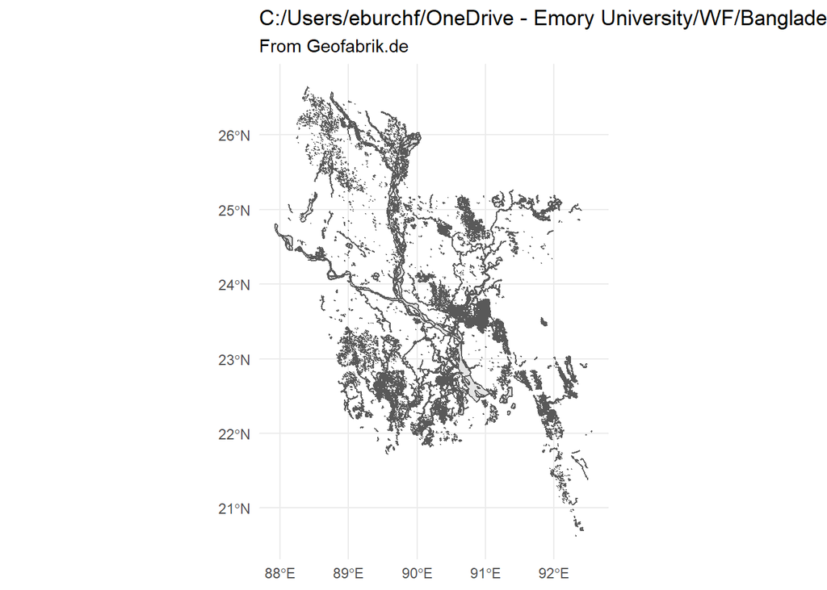

```r
water[[3]]
```

```r
roads <- inspect_shp(shp_list[12])
```

```
## [1] "C:/Users/eburchf/OneDrive - Emory University/WF/Bangladesh/data/gis_osm_roads_free_1.shp is a LINESTRING with 331452 observations."
```

```r
roads[[2]]
```

```
##  [1] residential    trunk          primary        tertiary       service
##  [6] pedestrian     unclassified   secondary      trunk_link     living_street
## [11] secondary_link primary_link   footway        path           track
## [16] unknown        bridleway      steps          track_grade1   track_grade4
## [21] tertiary_link  cycleway       track_grade3   track_grade2   track_grade5
## 25 Levels: bridleway cycleway footway living_street path pedestrian ... unknown
```

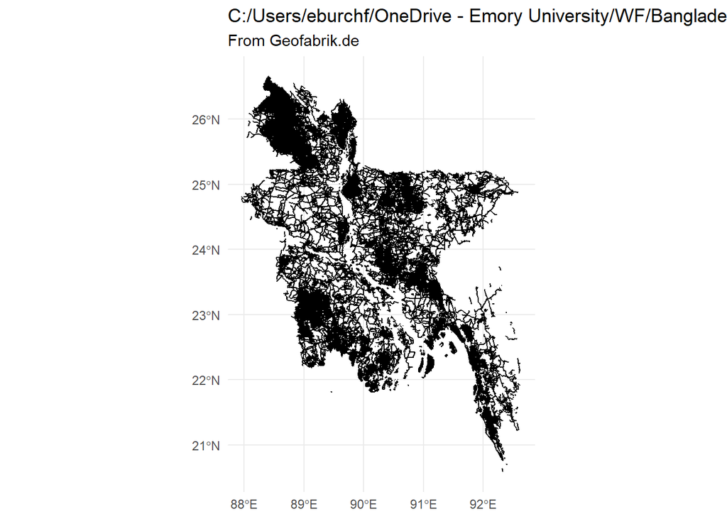

```r
roads[[3]]
```

If you want to learn more about working with OSM in `R`, you can also check out the [`osmdata`](https://cran.r-project.org/web/packages/osmdata/vignettes/osmdata.html) package, which looks really helpful if you want to pull data directly from OSM.